# PROBLEM :1 WHOLESALE CUSTOMER ANALYSIS

## 2.6. Construct a contingency table of Gender and Intent to Graduate at 2 levels (Yes/No). The Undecided students are not considered now and the table is a 2x2 table. Do you think the graduate intention and being female are independent events?

```python
ct=pd.crosstab(df['Gender'],df['Grad Intention'] )
block = pd.DataFrame(ct)
block[['Yes','No']]
```

| Grad Intention Gender | Yes | No |
| --- | --- | --- |
| Female | 11 | 9 |
| Male | 17 | 3 |

For 2 events to be independent, following condition is to be satified

P(A ∩ B) = P(A) * P(B)

So, P (Grad Intention ∩ Female) = P(Grad Intention) * P(Female)

P(Female) = 20/40 = 0.5

P(Grad Intention) = 28/40 = 0.7

P(Grad Intention) * P(Female) = 0.5 × 0.7 = 0.35

P (Grad Intention ∩ Female) = 11/40 = 0.275

This is not independent events as probability multiplication of both events is not equal to combined event, so being a Grad Intention and being female are not independent events.

## 2.7. Note that there are four numerical (continuous) variables in the data set, GPA, Salary, Spending, and Text Messages. Answer the following questions based on the data

2.7.1. If a student is chosen randomly, what is the probability that his/her GPA is less than 3?

```python
pd.crosstab(df['Gender'],df['GPA'])
```

| GPA Gender | 2.3 | 2.4 | 2.5 | 2.6 | 2.8 | 2.9 | 3.0 | 3.1 | 3.2 | 3.3 | 3.4 | 3.5 | 3.6 | 3.7 | 3.8 | 3.9 |
| --- | --- | --- | --- | --- | --- | --- | --- | --- | --- | --- | --- | --- | --- | --- | --- | --- |
| Female | 1 | 1 | 2 | 0 | 1 | 3 | 5 | 2 | 4 | 3 | 2 | 4 | 1 | 2 | 1 | 1 |
| Male | 0 | 0 | 4 | 2 | 2 | 1 | 2 | 5 | 2 | 2 | 5 | 2 | 2 | 0 | 0 | 0 |

```python
print('Probability that a student is chosen at random given his/her GPA is less than 3 =',17/62)
```

```
Probability that a student is chosen at random given his/her GPA is less than 3 = 0.27419354838709675
```

2.7.2. Find the conditional probability that a randomly selected male earns 50 or more. Find the conditional probability that a randomly selected female earns 50 or more.

```python
pd.crosstab(df['Gender'],df['Salary'])
```

| Salary Gender | 25.0 | 30.0 | 35.0 | 37.0 | 37.5 | 40.0 | 42.0 | 45.0 | 47.0 | 47.5 | 50.0 | 52.0 | 54.0 | 55.0 | 60.0 | 65.0 | 70.0 | 78.0 | 80.0 |
| --- | --- | --- | --- | --- | --- | --- | --- | --- | --- | --- | --- | --- | --- | --- | --- | --- | --- | --- | --- |
| Female | 0 | 5 | 1 | 0 | 1 | 5 | 1 | 1 | 0 | 1 | 5 | 0 | 0 | 5 | 5 | 0 | 1 | 1 | 1 |
| Male | 1 | 0 | 1 | 1 | 0 | 7 | 0 | 4 | 1 | 0 | 4 | 1 | 1 | 3 | 3 | 1 | 0 | 0 | 1 |

```python
print('From the contigency table we can find that the total number of male candidates who earn 50 or more is 14')
print('From the contigency table we can find that the total number of female candidates who earn 50 or more is 18')
```

[output not shown]

```python
print('The probability that a randomly selected male earns 50 or more is',14/29)
print('The probability that a randomly selected female earns 50 or more is',18/33)
```

```
The probability that a randomly selected male earns 50 or more is 0.4827586206896552
The probability that a randomly selected female earns 50 or more is 0.5454545454545454
```

## 2.8 Note that there are four numerical (continuous) variables in the data set, GPA, Salary, Spending, and Text Messages. For each of them comment whether they follow a normal distribution. Write a note summarizing your conclusions

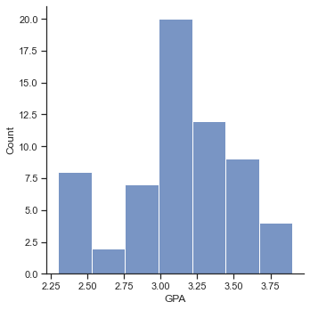

```python
sns.displot(df['GPA'])
plt.show()
```

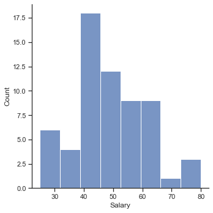

```python
sns.displot(df['Salary'])
plt.show()
```

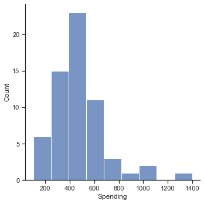

```python
sns.displot(df['Spending'])
plt.show()
```

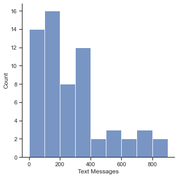

```python
sns.displot(df['Text Messages'])
plt.show()
```

# Problem 3

```python
abc= pd.read_csv("A+&+B+shingles.csv")
```

```python
abc
```

|  | A | B |
| --- | --- | --- |
| 0 | 0.44 | 0.14 |
| 1 | 0.61 | 0.15 |
| 2 | 0.47 | 0.31 |
| 3 | 0.30 | 0.16 |
| 4 | 0.15 | 0.37 |
| 5 | 0.24 | 0.18 |
| 6 | 0.16 | 0.42 |
| 7 | 0.20 | 0.58 |
| 8 | 0.20 | 0.25 |
| 9 | 0.20 | 0.41 |
| 10 | 0.26 | 0.17 |
| 11 | 0.14 | 0.13 |
| 12 | 0.33 | 0.23 |
| 13 | 0.13 | 0.11 |
| 14 | 0.72 | 0.10 |
| 15 | 0.51 | 0.19 |
| 16 | 0.28 | 0.22 |
| 17 | 0.39 | 0.44 |
| 18 | 0.39 | 0.11 |
| 19 | 0.25 | 0.11 |
| 20 | 0.16 | 0.31 |
| 21 | 0.20 | 0.43 |
| 22 | 0.22 | 0.26 |
| 23 | 0.42 | 0.18 |
| 24 | 0.24 | 0.44 |
| 25 | 0.21 | 0.43 |
| 26 | 0.49 | 0.16 |
| 27 | 0.34 | 0.52 |
| 28 | 0.36 | 0.36 |
| 29 | 0.29 | 0.22 |
| 30 | 0.27 | 0.39 |
| 31 | 0.40 | NaN |
| 32 | 0.29 | NaN |
| 33 | 0.43 | NaN |
| 34 | 0.34 | NaN |
| 35 | 0.37 | NaN |

```python
abc.describe(include='all').T
```

|  | count | mean | std | min | 25% | 50% | 75% | max |
| --- | --- | --- | --- | --- | --- | --- | --- | --- |
| A | 36.0 | 0.316667 | 0.135731 | 0.13 | 0.2075 | 0.29 | 0.3925 | 0.72 |
| B | 31.0 | 0.273548 | 0.137296 | 0.10 | 0.1600 | 0.23 | 0.4000 | 0.58 |

## 3.1 Do you think there is evidence that means moisture contents in both types of shingles are within the permissible limits? State your conclusions clearly showing all steps.

```python
A= abc.copy()
del A['B']
A
```

|  | A |
| --- | --- |
| 0 | 0.44 |
| 1 | 0.61 |
| 2 | 0.47 |
| 3 | 0.30 |
| 4 | 0.15 |
| 5 | 0.24 |
| 6 | 0.16 |
| 7 | 0.20 |
| 8 | 0.20 |
| 9 | 0.20 |
| 10 | 0.26 |
| 11 | 0.14 |
| 12 | 0.33 |
| 13 | 0.13 |
| 14 | 0.72 |
| 15 | 0.51 |
| 16 | 0.28 |
| 17 | 0.39 |
| 18 | 0.39 |
| 19 | 0.25 |
| 20 | 0.16 |
| 21 | 0.20 |
| 22 | 0.22 |
| 23 | 0.42 |
| 24 | 0.24 |
| 25 | 0.21 |
| 26 | 0.49 |
| 27 | 0.34 |
| 28 | 0.36 |
| 29 | 0.29 |
| 30 | 0.27 |
| 31 | 0.40 |
| 32 | 0.29 |
| 33 | 0.43 |
| 34 | 0.34 |
| 35 | 0.37 |

3.1 Do you think there is evidence that means moisture contents in both types of shingles are within the permissible limits? State your conclusions clearly showing all steps.

FOR A

H0 : mean moisture content <=0.35

HA : mean moisture content > 0.35

Level of Significance = 0.05

```python
import math
from scipy.stats import ttest_1samp
t_statistic,p_value = ttest_1samp(A,0.35)
print('One sample t test\nt statistic : {0} p_value{1}'. format (t_statistic,p_value/2))
```

```
One sample t test
t statistic : [-1.47350463] p_value[0.07477633]
```

Here the pvalue is 0.07477633 which is greater than the level of significANCE 0.05. Therefore we have no reason to reject the null hypothesis as the p value is greater than the level of significance

FOR B

```python
B=abc.copy()
del B['A']
B
```

|  | B |
| --- | --- |
| 0 | 0.14 |
| 1 | 0.15 |
| 2 | 0.31 |
| 3 | 0.16 |
| 4 | 0.37 |
| 5 | 0.18 |
| 6 | 0.42 |
| 7 | 0.58 |
| 8 | 0.25 |
| 9 | 0.41 |
| 10 | 0.17 |
| 11 | 0.13 |
| 12 | 0.23 |
| 13 | 0.11 |
| 14 | 0.10 |
| 15 | 0.19 |
| 16 | 0.22 |
| 17 | 0.44 |
| 18 | 0.11 |
| 19 | 0.11 |
| 20 | 0.31 |
| 21 | 0.43 |
| 22 | 0.26 |
| 23 | 0.18 |
| 24 | 0.44 |
| 25 | 0.43 |
| 26 | 0.16 |
| 27 | 0.52 |
| 28 | 0.36 |
| 29 | 0.22 |
| 30 | 0.39 |
| 31 | NaN |
| 32 | NaN |
| 33 | NaN |
| 34 | NaN |
| 35 | NaN |

H0 : mean moisture content <=0.35

HA : mean moisture content > 0.35

Level of Significance = 0.05

Here the sample size is 31 and the population standard deviation is not known. So we use One Sample t Test

```python
t_statistic,p_value = ttest_1samp(B,0.35, nan_policy='omit')
print('One sample t test \nt statistic: {0} p value: {1} '.format(t_statistic, p_value/2))
```

```
One sample t test
t statistic: [-3.1003313069986995] p value: [0.0020904774003191826]
```

## 3.2 Do you think that the population mean for shingles A and B are equal? Form the hypothesis and conduct the test of the hypothesis. What assumption do you need to check before the test for equality of means is performed?

TO CONTINUE WITH THE TEST,WE SHOULD MAKE SURE THAT CERTAIN CONDITIONS ARE SATISFIED

HO : mean moisture of A is equal to the mean moisture of B

HA : mean moisture of A is not equal to the mean moisture of B

Level of Significance = 0.05

Here we have two samples and the population standard deviation is not known.

As we are testing the equality between two samples A and B, we use 2 sample T test

```python
from scipy.stats import ttest_ind
t_statistic,p_value = ttest_ind(abc['A'],abc['B'] , nan_policy ='omit')
print('tstat',t_statistic)
print('p_value',p_value)
```

```
tstat 1.2896282719661123
p_value 0.2017496571835306
```

Here the pvalue is 0.2017496571835306 which is greater than the level of significance 0.05. Therefore we have no evidence to reject the null hypothesis as the p value is greater than the level of significance

Therefore we can conclude that the mean moisture content of A is equal to the mean moisture content of B